# Model Evaluation

11/15/2020

## Overview

- Introduction to Time to Event Data
- Introduction to classical Model Evaluation Tools
- Integrated Brier Score
- Concordance-Index
- Discussion
- R- Implementation
- Advancements & Novel Considerations
- Recommendation

## Time-to Event Studies

- Analysis working with right censored data
- Highly relevant for clinicians in the field of medical statistics e.g. looking at when a patient dies or when he gets a disease (clinical/epidemiological studies)
- In Economics/finance e.g. to examine when a subject/borrower will default or when a subject will find/lose a job
- Operations research to predict the time a machine will break

## Basic structure

- Time T and Survival S
- Hazard h(t,x) is the eminent probability of death a specific point in time
- Capital H is the cumulative hazard
- non-parametric hazard models (KM) vs.semi-parametric proportional hazard model
- From hazard to cumulative hazard to survival
- Survival Probability

## Model Evaluation - Considerations

1. *What type of study are we dealing with?*

**Diagnostic vs. Prognostic Study**

1. *What are the components of our model evaluation metric?*

**Discrimination**: How well are we able to classify subjects ? Are we able to correctly discriminate between e.g. sick and healthy patients ?

**Calibration**: How concise is our prediction accuracy ? More recently also:

**Clinical Usefulness**: Does it make sense to implement our model in the first place? Will our model create more benefits than harm?

## Classical Model Evaluation Tools

**Classification Tasks**

**Regression Tasks**

- Mean Absolute Error (mean absolute error)
- Mean Squared Error
- Brier Score
- R^2

### Brier Score

- Specific Point in time

### Confusion Matrix

**Sensitivity**:

- deals with values above the threshold among the subject group which do endure an event
- Another common name for Sensitivity is the true positive rate.

\(TPF = \frac{TP}{TP+FN}\)

**Specificity**:

\(TNR = \frac{TN}{TN+FP}\)

## Brier Score - Methods

## ROC/AUC/Concordance Statistics - Methods

## Why cant we use traditional model evaluation tools for time to event studies?

- Working with censored data ``
- Right censored data (event after follow up) vs. left censored data (event was not recorded when it occured intially)
- We need to estimate survival of patients without having data on e.g. death
- Also, we need to provide measure over time

Early approaches: - excluding subjects with right censored data and only evaluate on the complete data

## From ROC to C-Statistic to C-index

- Advancement of ROC/AUC
- Further modification leads to c-index
- concordance pairs divided
- concordance == x1>x2-> y1>y2
- Harell’s C

## c-index

- studying pairs of subjects
- addressing right censored data via inverse of the probability of censoring weighted estimate (of concordance probability)
- kendall’s tau
- Summary measure (over all time) based on the AUC

\(C-index = \frac{\Delta_j \times \sum_{i,j}1_{Ti>Tj} \times 1_{\eta_i>\eta_j}} {\Delta_j \times \sum_{i,j}1_{Ti>Tj}}\)

## mlr3 Proba Applications:

- van Houwelingen’s Alpha Calibration
- van Houwelingen’s Beta Calibration
- Integrated Graf Score
- Integrated Log Loss
- Log Loss

Further measures via survAUC package:

- Uno’s AUC/TPR/TNR
- Song and Zhou’s AUC/TNR/TPR
- Chambless and Diao’s AUC
- Hung and Chiang’s AUC

[output not shown]

```
##
## The c-index for right censored event times
##
## Prediction models:
##
##    Cox X1    Cox X2 Cox X1+X2       RSF
##    Cox X1    Cox X2 Cox X1+X2       RSF
##
## Right-censored response of a survival model
##
## No.Observations: 500
##
## Pattern:
##                 Freq
##  event          301
##  right.censored 199
##
## Censoring model for IPCW: marginal model (Kaplan-Meier for censoring distribution)
##
## No data splitting: either apparent or independent test sample performance
##
## Estimated C-index in %
##
## $AppCindex
##           time=1 time=2 time=3 time=4 time=5 time=6 time=7 time=8 time=9
## Cox X1      54.4   52.4   55.6   55.1   55.8   56.6   56.1   56.1   56.2
## Cox X2      78.2   78.1   74.0   73.3   72.5   72.1   72.0   71.8   71.5
## Cox X1+X2   76.8   77.7   75.5   74.6   74.4   74.5   74.2   74.2   73.9
## RSF         91.0   82.7   80.2   78.0   77.2   76.6   75.8   75.3   74.3
##           time=10 time=11 time=12 time=13 time=14 time=15
## Cox X1       56.2    56.2    56.2    56.3    56.3    56.3
## Cox X2       71.7    71.7    71.8    71.6    71.6    71.6
## Cox X1+X2    74.1    74.2    74.3    74.2    74.2    74.2
## RSF          73.9    73.9    73.8    73.9    73.9    73.9
```

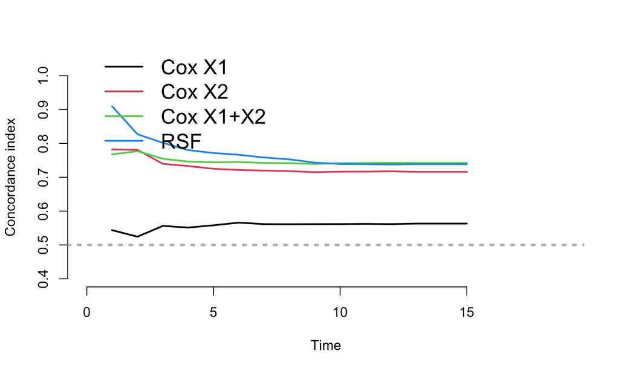

## IBS

- called cumulative predictive error curves == continuous ranked probability score (crps)
- area under the prediction error curve
- Integral over all points in time to get one summary value henceforth called “integrated” BS
- able to build a R^2 like measure where we divide MSE of a model with a different MSE of reference model

For the Individual:

\[L(S,t|t^*) = [(S(t^*)^2)I(t)\leq t^*, \delta =1)(\frac{1}{G(t)})]\] \[+ [((1-S(t^*))^2)I(t>t^*)(\frac{1}{G(t^*)})]\]

- Where L is a loss function of the S(the probability that the event of interest has not taken place yet) and time
- t is the time of the event (death) and t* the time before death
- G(t) is the P(C>t), so where the censored time is longer than the time (in mlr3proba via survfit == KM Estimate)
- When selecting integrated == FALSE then we looking at specific time

## For the population mean:

\[ L(S,t|t^*) = \frac{1}{N}\displaystyle\sum^N_{i=1}L(S_i,t_i|t^*) \tag{9} \]

### Mean Population:

\[L(S,t|t^*) = \frac{1}{NT}\displaystyle\sum^N_{i=1}\displaystyle\sum ^T_{j=1}L(S_i,t_i|t^*)\]

- N = Number of observations
- S_i is the predicted survival function

## If we take

```
## No covariates  specified: Kaplan-Meier for censoring times used for weighting.
```

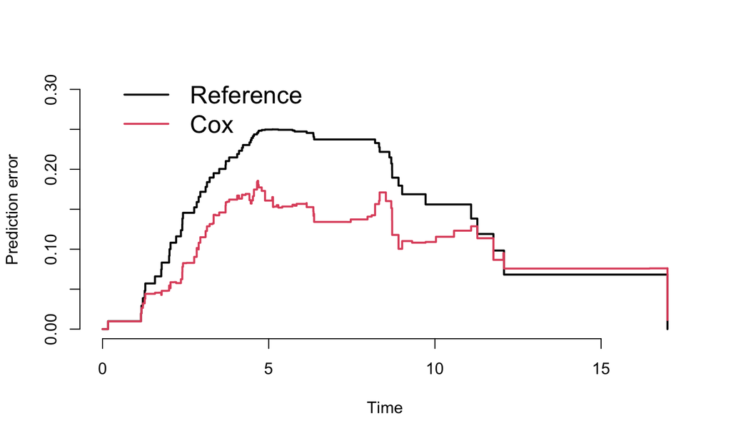

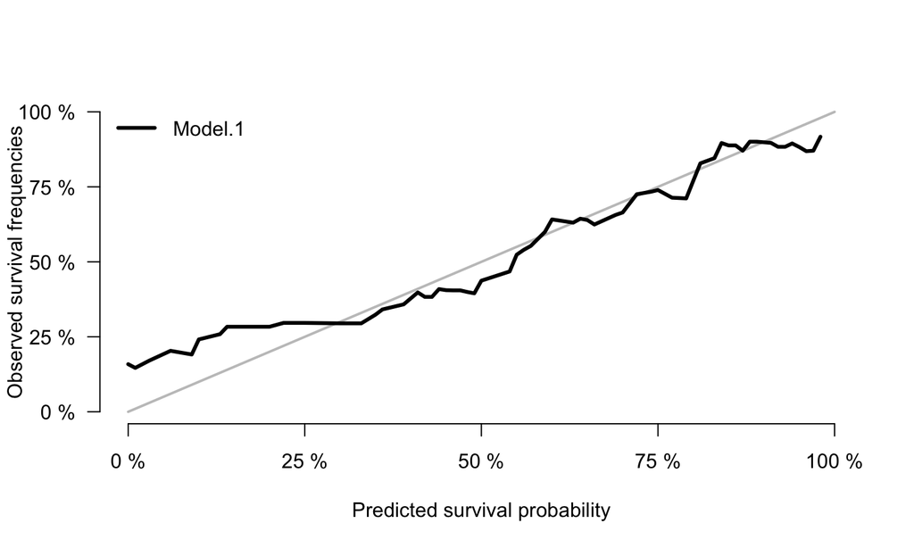

```
##
## Prediction error curves
##
## Prediction models:
##
## Reference    Cox.X1    Cox.X2 Cox.X1.X2
## Reference    Cox.X1    Cox.X2 Cox.X1.X2
##
## Right-censored response of a survival model
##
## No.Observations: 1000
##
## Pattern:
##                 Freq
##  event          574
##  right.censored 426
##
## IPCW: marginal model
##
## No data splitting: either apparent or independent test sample performance
##
## Cumulative prediction error, aka Integrated Brier score  (IBS)
##  aka Cumulative rank probability score
##
## Range of integration: 0 and time=1 time=2 time=3 time=4 time=5 time=6 time=7 time=8 time=9 time=10 time=11 time=12 time=13 time=14 time=15 :
##
##
## Integrated Brier score (crps):
##
##           IBS[0;time=1) IBS[0;time=2) IBS[0;time=3) IBS[0;time=4) IBS[0;time=5)
## Reference         0.011         0.035         0.065         0.096         0.121
## Cox.X1            0.011         0.035         0.065         0.094         0.118
## Cox.X2            0.011         0.033         0.057         0.079         0.096
## Cox.X1.X2         0.011         0.033         0.056         0.076         0.091
##           IBS[0;time=6) IBS[0;time=7) IBS[0;time=8) IBS[0;time=9)
## Reference         0.141         0.157         0.168         0.176
## Cox.X1            0.136         0.150         0.161         0.167
## Cox.X2            0.109         0.119         0.126         0.131
## Cox.X1.X2         0.103         0.111         0.118         0.122
##           IBS[0;time=10) IBS[0;time=11) IBS[0;time=12) IBS[0;time=13)
## Reference          0.180          0.182          0.182          0.181
## Cox.X1             0.170          0.172          0.172          0.171
## Cox.X2             0.134          0.135          0.135          0.135
## Cox.X1.X2          0.124          0.124          0.124          0.123
##           IBS[0;time=14) IBS[0;time=15)
## Reference          0.179          0.176
## Cox.X1             0.169          0.167
## Cox.X2             0.134          0.133
## Cox.X1.X2          0.122          0.121
```

```
##
## Prediction error curves
##
##
## No data splitting: either apparent or independent test sample performance
```

```
##
##  AppErr
##     time n.risk Reference Cox.X1 Cox.X2 Cox.X1.X2
## 1  0.000   1000     0.000  0.000  0.000     0.000
## 2  2.907    750     0.153  0.150  0.126     0.120
## 3  4.989    500     0.233  0.223  0.169     0.159
## 4  7.738    250     0.246  0.230  0.181     0.166
## 5 21.394      0     0.003  0.006  0.015     0.010
```

## Plotting the whole damn thing

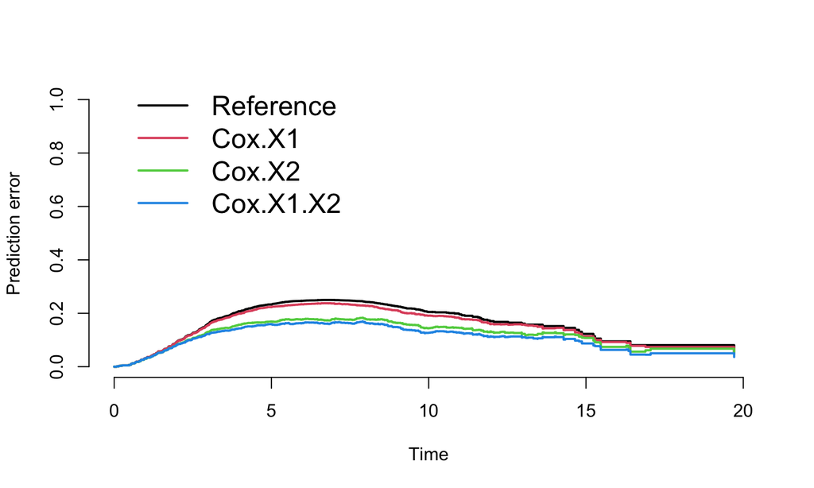

## Discussion

- Integrated Brier Score accounts for both calibration and discrimination
- Irrespective, neither model accounts and leaves room for improvement

## Literature

Introduction:

- Steyerberg, E. W., Vickers, A. J., Cook, N. R., Gerds, T., Gonen, M., Obuchowski, N., … & Kattan, M. W. (2010). Assessing the performance of prediction models: a framework for some traditional and novel measures. Epidemiology (Cambridge, Mass.), 21(1), 128.

Brier Score:

- Graf, E., Schmoor, C., Sauerbrei, W., & Schumacher, M. (1999). Assessment and comparison of prognostic classification schemes for survival data. Statistics in medicine, 18(17‐18), 2529-2545.

## Advanced Literature on C-index:

- Antolini, L., Boracchi, P., & Biganzoli, E. (2005). A time‐dependent discrimination index for survival data. Statistics in medicine, 24(24), 3927-3944.
- Uno, H., Cai, T., Pencina, M. J., D’Agostino, R. B., & Wei, L. J. (2011). On the C‐statistics for evaluating overall adequacy of risk prediction procedures with censored survival data. Statistics in medicine, 30(10), 1105-1117.

## Comparative Study:

- Kattan, M. W., & Gerds, T. A. (2018). The index of prediction accuracy: an intuitive measure useful for evaluating risk prediction models. Diagnostic and prognostic research, 2(1), 7.